# Project Foundations for Data Science: FoodHub Data Analysis

### Context

The number of restaurants in New York is increasing day by day. Lots of students and busy professionals rely on those restaurants due to their hectic lifestyles. Online food delivery service is a great option for them. It provides them with good food from their favorite restaurants. A food aggregator company FoodHub offers access to multiple restaurants through a single smartphone app.

The app allows the restaurants to receive a direct online order from a customer. The app assigns a delivery person from the company to pick up the order after it is confirmed by the restaurant. The delivery person then uses the map to reach the restaurant and waits for the food package. Once the food package is handed over to the delivery person, he/she confirms the pick-up in the app and travels to the customer's location to deliver the food. The delivery person confirms the drop-off in the app after delivering the food package to the customer. The customer can rate the order in the app. The food aggregator earns money by collecting a fixed margin of the delivery order from the restaurants.

### Objective

The food aggregator company has stored the data of the different orders made by the registered customers in their online portal. They want to analyze the data to get a fair idea about the demand of different restaurants which will help them in enhancing their customer experience. Suppose you are hired as a Data Scientist in this company and the Data Science team has shared some of the key questions that need to be answered. Perform the data analysis to find answers to these questions that will help the company to improve the business.

### Data Description

The data contains the different data related to a food order. The detailed data dictionary is given below.

### Data Dictionary

- order_id: Unique ID of the order
- customer_id: ID of the customer who ordered the food
- restaurant_name: Name of the restaurant
- cuisine_type: Cuisine ordered by the customer
- cost: Cost of the order
- day_of_the_week: Indicates whether the order is placed on a weekday or weekend (The weekday is from Monday to Friday and the weekend is Saturday and Sunday)
- rating: Rating given by the customer out of 5
- food_preparation_time: Time (in minutes) taken by the restaurant to prepare the food. This is calculated by taking the difference between the timestamps of the restaurant's order confirmation and the delivery person's pick-up confirmation.
- delivery_time: Time (in minutes) taken by the delivery person to deliver the food package. This is calculated by taking the difference between the timestamps of the delivery person's pick-up confirmation and drop-off information

### Let us start by importing the required libraries

```python
# import libraries for data manipulation
import numpy as np
import pandas as pd

# import libraries for data visualization
import matplotlib.pyplot as plt
import seaborn as sns
```

### Understanding the structure of the data

```python
# read the data
df = pd.read_csv('https://raw.githubusercontent.com/notfakearcher/julian/main/04_projects/food_hub/foodhub_order.csv')
# returns the first 5 rows
df.head()
```

|  | order_id | customer_id | restaurant_name | cuisine_type | cost_of_the_order | day_of_the_week | rating | food_preparation_time | delivery_time |
| --- | --- | --- | --- | --- | --- | --- | --- | --- | --- |
| 0 | 1477147 | 337525 | Hangawi | Korean | 30.75 | Weekend | Not given | 25 | 20 |
| 1 | 1477685 | 358141 | Blue Ribbon Sushi Izakaya | Japanese | 12.08 | Weekend | Not given | 25 | 23 |
| 2 | 1477070 | 66393 | Cafe Habana | Mexican | 12.23 | Weekday | 5 | 23 | 28 |
| 3 | 1477334 | 106968 | Blue Ribbon Fried Chicken | American | 29.20 | Weekend | 3 | 25 | 15 |
| 4 | 1478249 | 76942 | Dirty Bird to Go | American | 11.59 | Weekday | 4 | 25 | 24 |

#### Observations:

The DataFrame has 9 columns as mentioned in the Data Dictionary. Data in each row corresponds to the order placed by a customer.

### **Question 1:** How many rows and columns are present in the data?

```python
# Determine shape (i.e. number of rows and columns of the dataframe)
df.shape
```

```
(1898, 9)
```

#### Observations:

The DataFrame has 1898 rows and 9 columns.

### **Question 2:** What are the datatypes of the different columns in the dataset? (The info() function can be used)

```python
# Use info() to print a concise summary of the DataFrame
df.info()
```

```
<class 'pandas.core.frame.DataFrame'>
RangeIndex: 1898 entries, 0 to 1897
Data columns (total 9 columns):
 #   Column                 Non-Null Count  Dtype
---  ------                 --------------  -----
 0   order_id               1898 non-null   int64
 1   customer_id            1898 non-null   int64
 2   restaurant_name        1898 non-null   object
 3   cuisine_type           1898 non-null   object
 4   cost_of_the_order      1898 non-null   float64
 5   day_of_the_week        1898 non-null   object
 6   rating                 1898 non-null   object
 7   food_preparation_time  1898 non-null   int64
 8   delivery_time          1898 non-null   int64
dtypes: float64(1), int64(4), object(4)
memory usage: 133.6+ KB
```

#### Observations:

- The DataFrame has 9 columns (indexed from 0 to 8) consisting of 1898 rows each.
- There is 1 float variable: cost_of_the_order.
- There are 4 integer variables: order_id, customer_id, food_preparation_time, delivery_time.
- There are 4 object variables: restaurant_name, cuisine_type, day_of_the_week, rating.

### **Question 3:** Are there any missing values in the data? If yes, treat them using an appropriate method

```python
# Check for missing values across each column
df.isna().sum()
```

```
order_id                 0
customer_id              0
restaurant_name          0
cuisine_type             0
cost_of_the_order        0
day_of_the_week          0
rating                   0
food_preparation_time    0
delivery_time            0
dtype: int64
```

#### Observations:

- The DataFrame has no missing values.

### **Question 4:** Check the statistical summary of the data. What is the minimum, average, and maximum time it takes for food to be prepared once an order is placed?

```python
# We will drop order_id from the analysis due to it's non-explanatory nature (all unique values)

# Numerical variables to explore
vars_numerical = ['cost_of_the_order', 'food_preparation_time', 'delivery_time']

# Nominal and Ordinal variables to explore
# Note that customer_id are codes for people so we consider it nominal in the analysis
vars_nominal_ordinal = ['customer_id', 'restaurant_name', 'cuisine_type', 'day_of_the_week', 'rating']
```

```python
# Show descriptive statistics for object columns in the dataframe
df_descriptives_object = df[vars_nominal_ordinal].astype({'customer_id': 'object'}).describe(include = 'object')
df_descriptives_object
```

|  | customer_id | restaurant_name | cuisine_type | day_of_the_week | rating |
| --- | --- | --- | --- | --- | --- |
| count | 1898 | 1898 | 1898 | 1898 | 1898 |
| unique | 1200 | 178 | 14 | 2 | 4 |
| top | 52832 | Shake Shack | American | Weekend | Not given |
| freq | 13 | 219 | 584 | 1351 | 736 |

```python
# Show descriptive statistics for numeric columns in the dataframe rounded to nearest 10th decimal
df_descriptives_numeric = df[vars_numerical].describe(include = 'number').round(1)
df_descriptives_numeric
```

|  | cost_of_the_order | food_preparation_time | delivery_time |
| --- | --- | --- | --- |
| count | 1898.0 | 1898.0 | 1898.0 |
| mean | 16.5 | 27.4 | 24.2 |
| std | 7.5 | 4.6 | 5.0 |
| min | 4.5 | 20.0 | 15.0 |
| 25% | 12.1 | 23.0 | 20.0 |
| 50% | 14.1 | 27.0 | 25.0 |
| 75% | 22.3 | 31.0 | 28.0 |
| max | 35.4 | 35.0 | 33.0 |

#### Observations:

- The minimum, average, and maximum time it takes for food to be prepared once an order is placed is 20, 27.4, 35 minutes, respectively.

### **Question 5:** How many orders are not rated?

```python
# Determine unique rating values to understand what "not rated" looks like in dataset
unique_rating_values = df['rating'].unique()
print(f'Unique order rating values: {unique_rating_values}')

# Condtion checking where orders are not rated (note: not rated is labeled as 'Not given')
cond = df['rating'] == 'Not given'

# Count number of orders are not rated (i.e. sum all True conditions)
not_rated_count = cond.sum()
print(f'Number of orders not raeted = {not_rated_count}')
```

```
Unique order rating values: ['Not given' '5' '3' '4']
Number of orders not raeted = 736
```

#### Observations:

- The label 'Not given' is used to identify orders that are not rated.
- There are 736 orders not rated.

### Exploratory Data Analysis (EDA)

### **Question 6:** Explore all the variables and provide observations on their distributions. (Generally, histograms, boxplots, countplots, etc. are used for univariate exploration)

```python
# Color list
clist = ['grey', 'red', 'green', 'black']

# References to plot on the x-axis
x1 = 'mean'
x2 = '50%'

# User defined function to plot histogram for numerical variable
def jra_univariate_hist_plot(df, var, ax, df_descriptives):
  p1 = sns.histplot(data = df, x = var, kde = True, color = clist[0], ax = ax)
  ax.set_title(f'Distribution of {var}')
  p1.set_xlabel(xlabel = '')
  p1.axvline(x = df_descriptives[var][x1], color = clist[1], linewidth = 3, label = x1)
  p1.axvline(x = df_descriptives[var][x2], color = clist[2], linewidth = 3, label = x2)
  p1.legend()

# User defined function to plot box_plot with jitter/striplolot overlay for numerical variable
def jra_univariate_box_plot(df, var, ax, df_descriptives):
  p2 = sns.boxplot(data = df, x = var, color = clist[0], ax = ax)
  p2.axvline(x = df_descriptives[var][x1], color = clist[1], linewidth = 3)
  p2.axvline(x = df_descriptives[var][x2], color = clist[2], linewidth = 3)
  sns.stripplot(data = df, x = var, color = clist[3], size = 3, alpha = 0.2, ax = ax)

# User defined function to plot count_plot with for categorical variables
def jra_univariate_count_plot(df, var, ax, top_n = 20):
  p1 = sns.countplot(data = df, y = var, color = clist[0], order = df[var].value_counts().iloc[:top_n].index, ax = ax)
  title = f'Distribution of {var}'
  if len(df[var].unique()) > top_n:
    title = f'Top {top_n} ' + title
  p1.set_title(title)
  p1.tick_params(axis = 'x', rotation = 0, labelsize = 8)
  x_lim = p1.get_xlim()[1]
  p1.set_xlim(0, x_lim + int(0.12 * x_lim))
  for p in p1.patches:
    p1.annotate(
      text = '{:d}'.format(int(p.get_width())),
      xy = (p.get_width(), p.get_y()+0.5),
      color = clist[3],
      weight = 'bold'
    )
```

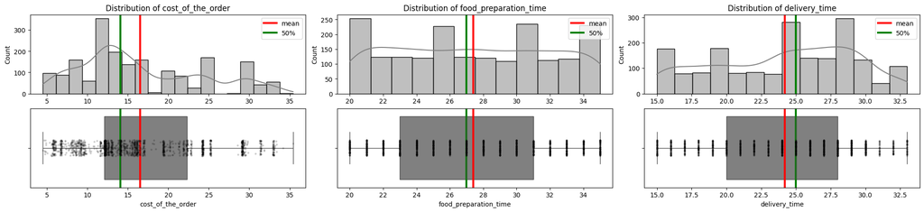

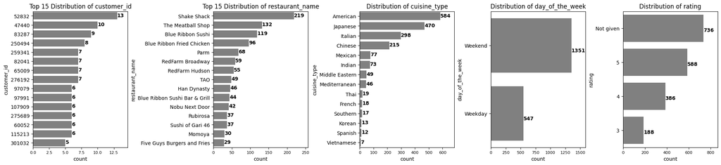

```python
# Univariate plots of numerical variables
fig, ax = plt.subplots(nrows = 2, ncols = len(vars_numerical), figsize = (20, 4.5), constrained_layout = True)
for row in range(2):
  for col in range(3):
    var = vars_numerical[col]
    jra_univariate_hist_plot(df, var, ax[row, col], df_descriptives_numeric) if row == 0 else jra_univariate_box_plot(df, var, ax[row, col], df_descriptives_numeric)
plt.show()

# Univariate plots of norminal and ordinal variables
fig, ax = plt.subplots(nrows = 1, ncols = len(vars_nominal_ordinal), figsize = (20, 4.5), constrained_layout = True)
# fig.tight_layout(pad = 10)
for col in range(len(vars_nominal_ordinal)):
  var = vars_nominal_ordinal[col]
  p1 = jra_univariate_count_plot(df, var, ax = ax[col], top_n = 15)
plt.show()
```

### **Question 7**: Which are the top 5 restaurants in terms of the number of orders received?

```python
# Group by restaurant_name and count orders for each
df_restaurant_orders = (
  df
  .groupby('restaurant_name')
  .aggregate(order_count = ('order_id', 'count'))
).reset_index().sort_values(by = 'order_count', ascending = False)

# Select top five restaurants by orders
df_restaurant_orders[:5]
```

|  | restaurant_name | order_count |
| --- | --- | --- |
| 136 | Shake Shack | 219 |
| 153 | The Meatball Shop | 132 |
| 21 | Blue Ribbon Sushi | 119 |
| 20 | Blue Ribbon Fried Chicken | 96 |
| 109 | Parm | 68 |

#### Observations:

The top 5 restaurants by orders are: (1) Shake Shack (with 219 orders), (2) The Meatball Shop (with 132 orders), (3) Blue Ribbon Sushi (with 119 orders), (4) Blue Ribbon Fried Chicken (with 96 orders), and (5) Parm (with 68 orders).

### **Question 8**: Which is the most popular cuisine on weekends?

```python
# Filter data on day_of_week = 'Weekend'
df_weekend = df.loc[df['day_of_the_week']=='Weekend', :]

# Group by cuisine and count orders for each
df_cuisine_orders = (
  df_weekend
  .groupby('cuisine_type')
  .aggregate(cuisine_count = ('cuisine_type', 'count'))
).reset_index().sort_values(by = 'cuisine_count', ascending = False)

# Select top cuisine by orders
df_cuisine_orders[:1]
```

|  | cuisine_type | cuisine_count |
| --- | --- | --- |
| 0 | American | 415 |

#### Observations:

The top cuisine by orders is American (with 415 orders).

### **Question 9**: What percentage of the orders cost more than 20 dollars?

```python
# Total orders
total_orders = df['order_id'].count()

# Total orders over 20 dollars
cond = df['cost_of_the_order'] > 20
total_orders_over_20 = df['cost_of_the_order'][cond].count()

# Percentage of orders > 20
percent_orders_over_20 = ((total_orders_over_20 / total_orders) * 100).round(1)
percent_orders_over_20
```

```
29.2
```

#### Observations:

Approximately 29.2% of the orders cost more than 20 dollars.

### **Question 10**: What is the mean order delivery time?

```python
# mean order delivery time
df_descriptives_numeric['delivery_time']['mean']
```

```
24.2
```

#### Observations:

The mean order delivery time is approximately 24.2 minutes.

### **Question 11:** The company has decided to give 20% discount vouchers to the top 3 most frequent customers. Find the IDs of these customers and the number of orders they placed

```python
# Group by customer_id and count orders for each
df_customer_orders = (
  df
  .groupby('customer_id')
  .aggregate(order_count = ('order_id', 'count'))
).reset_index().sort_values(by = 'order_count', ascending = False)

# Select top 3 customers by orders
df_customer_orders[:3]
```

|  | customer_id | order_count |
| --- | --- | --- |
| 116 | 52832 | 13 |
| 84 | 47440 | 10 |
| 333 | 83287 | 9 |

#### Observations:

The top 3 customer_id by orders are: (1) 52832 (with 13 orders), (2) 47440 (with 10 orders), and (3) 83287 (with 9 orders).

### **Question 12**: Perform a multivariate analysis to explore relationships between the important variables in the dataset. (It is a good idea to explore relations between numerical variables as well as relations between numerical and categorical variables)

### Multivariate Analysis

```python
# Plot correlations between relevant numerical variables
df_corr = df[vars_numerical].corr().round(1)
df_corr
```

|  | cost_of_the_order | food_preparation_time | delivery_time |
| --- | --- | --- | --- |
| cost_of_the_order | 1.0 | 0.0 | -0.0 |
| food_preparation_time | 0.0 | 1.0 | 0.0 |
| delivery_time | -0.0 | 0.0 | 1.0 |

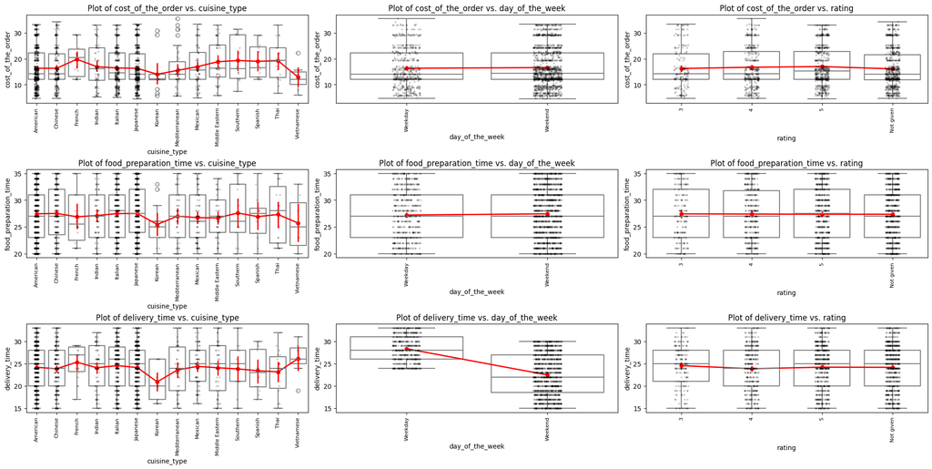

```python
# Explore bi-variate relationships between nominal/ordinal variables and numerical variables
# Note we exclude customer_id, and restaurant_name) due to the large number of categories
fig, ax = plt.subplots(nrows = len(vars_nominal_ordinal[2:]), ncols = len(vars_numerical), figsize = (20, 10), constrained_layout = True)
for i in range(2, len(vars_nominal_ordinal)):
  for j in range(len(vars_numerical)):
    x = vars_nominal_ordinal[i]
    y = vars_numerical[j]
    df = df.sort_values(by = x, ascending = True)
    title = f'Plot of {y} vs. {x}'
    p1 = sns.boxplot(data = df, x = x, y = y, color = clist[0], fill = False, ax = ax[j, i-2])
    p1.set_title(title)
    p1.tick_params(axis = 'x', rotation = 90, labelsize = 8)
    p2 = sns.pointplot(data = df, x = x, y = y, color = clist[1], linewidth = 2, ax = ax[j, i-2])
    p3 = sns.stripplot(data = df, x = x, y = y, color = clist[3], size = 3, alpha = 0.2, ax = ax[j, i-2])
plt.show()
```

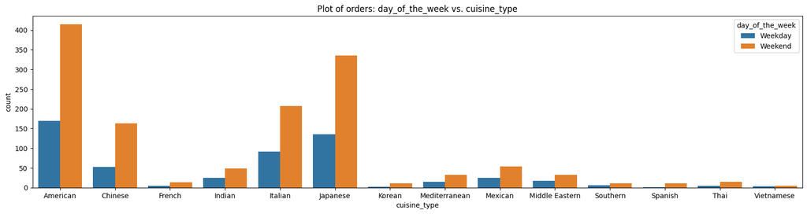

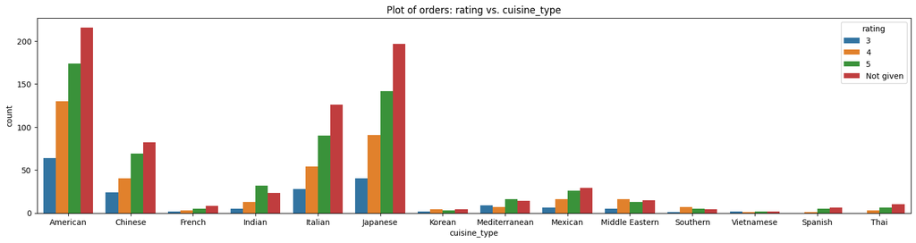

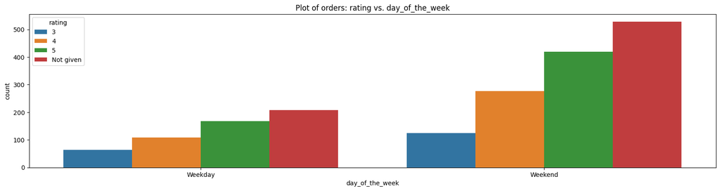

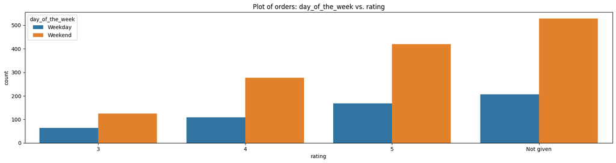

```python
# Explore bi-variate relationships between nominal/ordinal variables
# Note we exclude customer_id, and restaurant_name) due to the large number of categories
for i in range(2, len(vars_nominal_ordinal)):
  for j in range(2, len(vars_nominal_ordinal)):
    if (i != j):
      x = vars_nominal_ordinal[i]
      y = vars_nominal_ordinal[j]
      if (len(df[y].unique()) <= 5):
        plt.figure(figsize = (20, 4.5))
        title = f'Plot of orders: {y} vs. {x}'
        sns.countplot(data = df.sort_values(by = [y, x], ascending = True), x = x, hue = y)
        plt.title(label = title)
        plt.show()
```

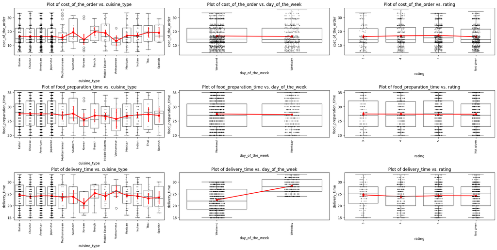

```python
# Explore bi-variate relationships between nominal/ordinal variables
# Note we exclude customer_id, and restaurant_name) due to the large number of categories
fig, ax = plt.subplots(nrows = len(vars_nominal_ordinal[2:]), ncols = len(vars_nominal_ordinal[2:]), figsize = (20, 10), constrained_layout = True)
for i in range(2, len(vars_nominal_ordinal)):
  for j in range(len(vars_numerical)):
    x = vars_nominal_ordinal[i]
    y = vars_numerical[j]
    title = f'Plot of {y} vs. {x}'
    p1 = sns.boxplot(data = df, x = x, y = y, color = clist[0], fill = False, ax = ax[j, i-2])
    p1.set_title(title)
    p1.tick_params(axis = 'x', rotation = 90, labelsize = 8)
    p2 = sns.pointplot(data = df, x = x, y = y, color = clist[1], linewidth = 2, ax = ax[j, i-2])
    p3 = sns.stripplot(data = df, x = x, y = y, color = clist[3], size = 3, alpha = 0.2, ax = ax[j, i-2])
plt.show()
```

#### Observations:

- The numerical variables (i.e. cost of the order, food preparation time, delivery time) are independent of each other as their correlations are approximately all equal to 0.
- Delivery times are higher on weekday compared to weekend.
- Frequency count of orders across the various nominal/ordinal variables (i.e. cuisine type, rating) are higher on weekend compared to weekday.

### **Question 13:** The company wants to provide a promotional offer in the advertisement of the restaurants. The condition to get the offer is that the restaurants must have a rating count of more than 50 and the average rating should be greater than 4. Find the restaurants fulfilling the criteria to get the promotional offer

```python
# Filter to include only rows where ratings were given (i.e. != 'Not given')
cond = df['rating'] != 'Not given'
df_given_ratings = df.copy().loc[cond,:].astype({'rating': 'int32'})

# Group by restaurant_name and count the ratings for each
df_restaurant_rating_counts = (
  df_given_ratings
  .groupby('restaurant_name')
  .aggregate(rating_count = ('rating', 'count'))
).reset_index().sort_values(by = 'rating_count', ascending = False)

# Group by restaurant_name and average the ratings for each
df_restaurant_rating_means = (
  df_given_ratings
  .groupby('restaurant_name')
  .aggregate(rating_mean = ('rating', 'mean'))
).reset_index().sort_values(by = 'rating_mean', ascending = False).round(1)

# Join df_restaurant_rating_counts and df_restaurant_rating_means on restaurant_name
df_restaurant_ratings = df_restaurant_rating_counts.merge(df_restaurant_rating_means, how = 'inner')

# Select restaurants with count greater 50
cond = (df_restaurant_ratings['rating_count'] > 50) & (df_restaurant_ratings['rating_mean'] > 4)
df_restaurant_ratings.loc[cond, :]
```

|  | restaurant_name | rating_count | rating_mean |
| --- | --- | --- | --- |
| 0 | Shake Shack | 133 | 4.3 |
| 1 | The Meatball Shop | 84 | 4.5 |
| 2 | Blue Ribbon Sushi | 73 | 4.2 |
| 3 | Blue Ribbon Fried Chicken | 64 | 4.3 |

#### Observations:

Restaurants having a rating count of more than 50 and average rating greater than 4 include: (1) Shake Shack (with 133 ratings averaging 4.3), (2) The Meatball Shop (with 84 ratings averaging 4.5), (3) Blue Ribbon Sushi (with 73 ratings averaging 4.2), and (4) Blue Ribbon Fried Chicken (with 64 ratings averaging 4.3).

### **Question 14:** The company charges the restaurant 25% on the orders having cost greater than 20 dollars and 15% on the orders having cost greater than 5 dollars. Find the net revenue generated by the company across all orders

```python
# Select relevant columns from DataFrame
cols = ['restaurant_name', 'cost_of_the_order']
df_revenue = df.loc[:, cols]

# Compute sales revenue with each order
df_revenue['sale_revenue'] = [(0.25 * x) if (x > 20) else (0.15 * x) if (x > 5) else 0 for x in df_revenue['cost_of_the_order']]

# Total net revenue across all orders
total_net_revenue = df_revenue['sale_revenue'].sum().round(2)
total_net_revenue
```

```
6166.3
```

#### Observations:

- The the net revenue generated by the company across all orders is $6166.30.

### **Question 15:** The company wants to analyze the total time required to deliver the food. What percentage of orders take more than 60 minutes to get delivered from the time the order is placed? (The food has to be prepared and then delivered)

```python
# Select relevant columns from DataFrame
cols = ['order_id', 'food_preparation_time', 'delivery_time']
df_order_time = df.loc[:, cols]

# Compute time from order to delivery for each order
df_order_time['order_to_delivery_time'] = df_order_time['food_preparation_time'] + df_order_time['delivery_time']

# Total orders that take > 60 mins from order to delivery
cond = df_order_time['order_to_delivery_time'] > 60
total_order_times_over_60 = df_order_time['order_to_delivery_time'][cond].count()

# Percentage orders that take > 60 mins from order to delivery
percent_order_times_over_60 = ((total_order_times_over_60 / total_orders) * 100).round(1)
percent_order_times_over_60
```

```
10.5
```

#### Observations:

- Approximately 10.5% of orders take more than 60 minutes to get delivered from the time the order is placed.

### **Question 16:** The company wants to analyze the delivery time of the orders on weekdays and weekends. How does the mean delivery time vary during weekdays and weekends?

```python
# Group by day_of_the_week and average delivery_time for each
df_day_of_the_week_delivery_times = (
  df
  .groupby('day_of_the_week')
  .aggregate(delivery_time_mean = ('delivery_time', 'mean'))
).reset_index().sort_values(by = 'delivery_time_mean', ascending = False).round(1)

df_day_of_the_week_delivery_times
```

|  | day_of_the_week | delivery_time_mean |
| --- | --- | --- |
| 0 | Weekday | 28.3 |
| 1 | Weekend | 22.5 |

```python
# Percent increase in delivery times on the Weekday vs Weekend
weekday_delivery_time = df_day_of_the_week_delivery_times['delivery_time_mean'][0]
weekend_delivery_time = df_day_of_the_week_delivery_times['delivery_time_mean'][1]
((weekday_delivery_time / weekend_delivery_time).round(3) - 1) * 100
```

```
25.8
```

#### Observations:

- Mean delivery time is higher on the weekday (28.3 mins) compared to the weekend (22.5 mins).
- There is approximately a 25.8% increase on delivery times from weekend to weekdays.

### Conclusion and Recommendations

### **Question 17:** What are your conclusions from the analysis? What recommendations would you like to share to help improve the business? (You can use cuisine type and feedback ratings to drive your business recommendations)

### Conclusions:

- Many customers do not give rating feedback on their orders.
- Over twice as many more orders happen on the weekend vs weekday.
- Longer delivery times on weekdays compared to weekends (approximately 25% more time).
- There are many more orders placed at some of the top cuisines (e.g. American, Japanese, Italian, Chinese).
- There are many more orders placed at some of the top restaurants (e.g. Shake Shack, The meatball Shop, Blue Ribbon Sushi, Blue Ribbon Fried Chicken, Parm).

### Recommendations:

- FoodHub should get more detailed feedback from customers on their experience along with the ratings, since you do not know the reason for low ratings when they exist.
- FoodHub should cater more to the popular cuisines, i.e. American, Japanese, Italian, and Chinese cuisines. This is where most of the company's revenue is made.
- FoodHub should limit the number of restaurants served from non-popular cuisines and maybe strategically pick ones that are also closer to the popular restaurants for convenience.
- FoodHub should try and understand how to improve delivery times during off-peak operations (i.e. during the weekday); maybe hire more delivery people during the weekday.